# Lagerquist_K_7

Kyle Lagerquist

10/11/2018

```r
library("rvest")
library("tidyverse")
library("lubridate")
```

# Sportsbook Review is an online database for sports and wagering data.

# My goal for this webscraper is to scrape all information about outcome of NFL games, and wagers made.

# Using this data I am interested in how the public’s wagering information can be used to predict the

# outcome of NFL games.

QUESTIONS TO ANSWER

# 1) Is there a relationship between game start time and wagers placed / money placed?

# Returns a vector of all of the data belonging to the given class from the URL

```r
getDataByClass <- function(class,siteURL) {
  siteURL %>% html_nodes(class) %>% html_text()
}
```

# Function that returns a numerical vector of the average bet placed on each team

```r
getBetSize <- function(siteURL,dateOfGame) {
  numGames <- length(getDataByClass("._36GvL",siteURL))
  # allocate storage for vector that will be filled with the average size of each bet
  betSizes <- vector(mode="character", length=numGames)
  counter <- 1
  # iterate through the total games played this day (total teams divided by 2)
  # for each game there are two average bets that need to be retrieved
  # each bet will be retrieved from using its XPATH
  for (i in 3:((numGames/2)+2)) {
    for (j in 1:2) {
      # the XPATH of the current average bet
      path <- paste(c("//*[@id='bettingOddsGridContainer']",
                      "/div[2]/div[",i,"]/div[2]/div/div/section[4]/main/div[",j,"]"),collapse="")
      # retrieve the average bet
      bet <- siteURL %>% html_nodes(xpath=path) %>% html_text()
      # replace the item in the allocated vector with the retrieved bet
        ifelse(nchar(bet) > 0, betSizes[counter] <- bet,betSizes[counter] <- "9999999")
      counter <- counter + 1
    }
  }
  # return the numerical vector and remove the $ symbol
  as.numeric(gsub("\\$","",betSizes))
}
```

# Returns a data frame of all compiled NFL data from the select day.

# Takes the read HTML and day of the games in as parameters.

```r
getDF <- function(siteURL,dateOfGame) {
  # all teams that played
  teamNames <- getDataByClass("._36GvL",siteURL)
  # the spread for each team that played
  allSpreads <- getDataByClass("._3Nv_7",siteURL)
  # the wagers placed and then the percentage of wqgers placed
  mixedWagers <- getDataByClass("._3O8kW",siteURL)
  # the time each game was played
  timeData <- getDataByClass("._3sYWn",siteURL)

  timeData <- gsub(" AM","",timeData)
  timeData <- gsub(" PM","",timeData)

  # replace all invalid half values (½) with valid half values and change to numeric
  changedSpreads <- as.numeric(gsub("½",".5",allSpreads))

  # remove the commas, % sign, and $ sign
  mixedWagers <- gsub(",","",mixedWagers)
  mixedWagers <- gsub("%","",mixedWagers)
  mixedWagers <- gsub("\\$","",mixedWagers)
  mixedWagers <- as.numeric(mixedWagers)

  # retrieve all of the average bets placed on everyteam
  allAvgBets <- getBetSize(siteURL,dateOfGame)

  # retrieve the final score from all games on the given gameday
  # once the URL is retrvieved, a vector is returned of all of the final scores
  finalScoresURL <- read_html(paste(c("https://www.sportsbookreview.com/betting-odds/nfl-football/?date=",dateOfGame),collapse=""))
  allScores <- finalScoresURL %>% html_nodes(xpath="//*[@class='_1Y3rN _2trL6 _308Yc']/div") %>% html_text()

  # create vectors for each column that will go into the data frame
  # in every vector defined above the data is spread throughout in a defined pattern
  # for each variable the sequence must be abstracted that will be turned into a column
  # this ensures that each observation represents one football game
  awayTeamNames <- teamNames[seq(1, length(teamNames), 2)]
  homeTeamNames <- teamNames[seq(2, length(teamNames), 2)]
  awayTeamSpreads <- changedSpreads[seq(1, length(changedSpreads), 2)]
  homeTeamSpreads <- changedSpreads[seq(2, length(changedSpreads), 2)]
  awayFinalScore <- allScores[seq(1, length(allScores), 2)]
  homeFinalScore <- allScores[seq(2, length(allScores), 2)]
  awayWagersPlaced <- mixedWagers[seq(1, length(mixedWagers), 8)]
  homeWagersPlaced <- mixedWagers[seq(3, length(mixedWagers), 8)]
  awayWagersPlacedPercent <- mixedWagers[seq(2, length(mixedWagers), 8)]
  homeWagersPlacedPercent <- mixedWagers[seq(4, length(mixedWagers), 8)]
  awayTotalWagered <- mixedWagers[seq(5, length(mixedWagers), 8)]
  homeTotalWagered <- mixedWagers[seq(7, length(mixedWagers), 8)]
  awayTotalWageredPercent <- mixedWagers[seq(6, length(mixedWagers), 8)]
  homeTotalWageredPercent <- mixedWagers[seq(8, length(mixedWagers), 8)]
  awayAverageBets <- allAvgBets[seq(1, length(allAvgBets), 2)]
  homeAverageBets <- allAvgBets[seq(2, length(allAvgBets), 2)]

  # create the data frame with all the neccessary columns
  compiledNFLData <- data.frame("time"=timeData,"away"=awayTeamNames,"home"=homeTeamNames,
                   "awaySpread"=awayTeamSpreads,"homeSpread"=homeTeamSpreads,
                   "awayFinalScore"=awayFinalScore,"homeFinalScore"=homeFinalScore,
                   "awayWagersPlaced"=awayWagersPlaced,"homeWagersPlaced"=homeWagersPlaced,
                   "awayWagersPlacedPercent"=awayWagersPlacedPercent,
                   "homeWagersPlacedPercent"=homeWagersPlacedPercent,
                   "awayTotalWagered"=awayTotalWagered,"homeTotalWagered"=homeTotalWagered,
                   "awayTotalWageredPercent"=awayTotalWageredPercent,
                   "homeTotalWageredPercent"=homeTotalWageredPercent,
                   "awayAverageBet"=awayAverageBets,"homeAverageBet"=homeAverageBets)

  # using the lubridate package, add a date object for the date of each game, and the day of the week of each game
  mutate(compiledNFLData,date=ymd(dateOfGame),dayOfWeek=wday(date,label = TRUE))
}
```

# Function that iterates over a list of days where an NFL game occured,

# the list of days are in YYYYMMDD format.

# Retrieves a data frame for the first game of the season and then appends every returned dataframe to it.

```r
getMultipleDays <- function() {
  # URL for all football data from 09/30/2018
  footballDataURL <- read_html("https://www.sportsbookreview.com/betting-odds/nfl-football/consensus?date=20180930")
  compiledNFLData <- getDF(footballDataURL,"20180906")

  # list of all days where an NFL game has occured in the 2018 season
  moreFootballDays <- c("20180909","20180910","20180913","20180916","20180917","20180923","20180920",
                        "20180924","20180927","20180930","20181001","20181004","20181007","20181008")
  # iterate through all days in the list
  for (oneDay in moreFootballDays) {
    # the URL for the consensus gambling data
    newURL <- paste(c("https://www.sportsbookreview.com/betting-odds/nfl-football/consensus?date=",oneDay),collapse="")
    newHTML <- read_html(newURL)
    # get the constructed dataframe for this day
    newData <- getDF(newHTML,oneDay)
    # append the data frame to all of the previously retrieved data
    compiledNFLData <- rbind(compiledNFLData,newData)
  }
  compiledNFLData
}

compiledNFLData <- getMultipleDays()
```

# Generates a scatter plot of the total amount of bets placed on a game vs. game start time on Sundays.

```r
graphBetsByTime <- function(df) {
  # add a column for total bets placed on the game
  total <- mutate(compiledNFLData,totalBets=awayWagersPlaced+homeWagersPlaced)
  # filter only games that were played on Sunday
  filt <- filter(total,dayOfWeek=="Sun")
  # create a scatter plot of the two variables
  ggplot(filt, aes(x=time, y=totalBets)) + geom_point() +
    labs(title = "Bets Per Start Time on Sundays",
         caption = "According to Sports Book Review")
}
```

# Generates a scatter plot of the total amount of money placed on a game vs. game start time on Sundays.

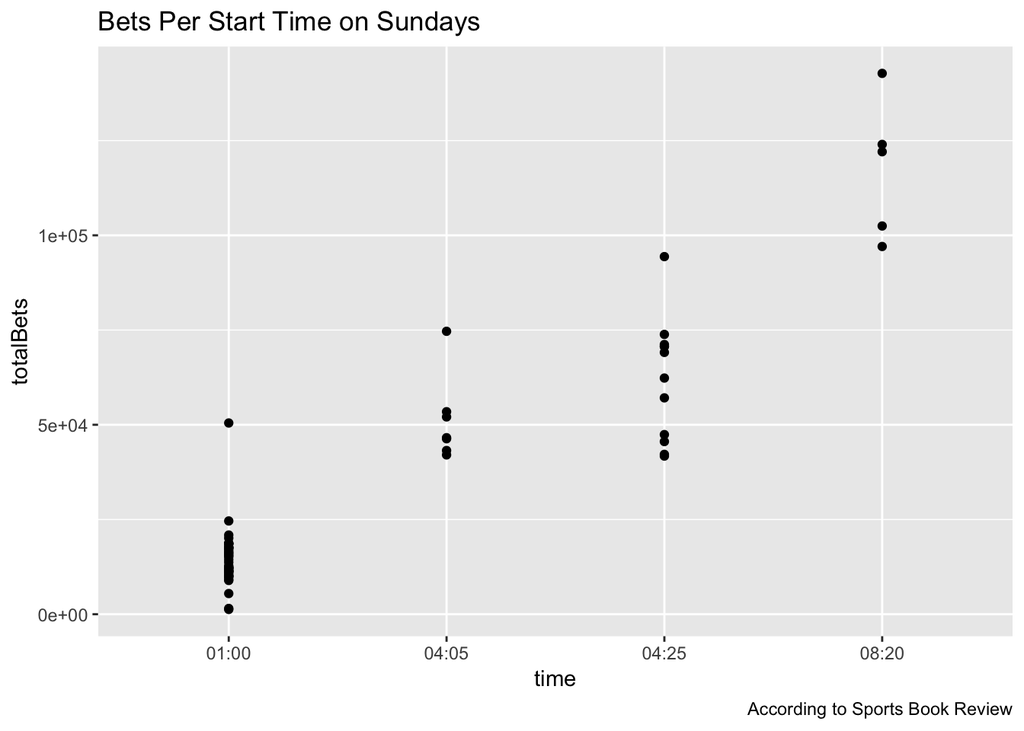

```r
graphTotalWageredByTime <- function(df) {
  # add a column for total money placed on the game
  total <- mutate(compiledNFLData,totalWagered=awayTotalWagered+homeTotalWagered)
  # filter only games that were played on Sunday
  filt <- filter(total,dayOfWeek=="Sun")
  # create a scatter plot of the two variables
  ggplot(filt, aes(x=time, y=totalWagered)) + geom_point() +
    labs(title = "Total Wagered Per Start Time on Sundays",
         caption = "According to Sports Book Review")
}

graphBetsByTime()
```

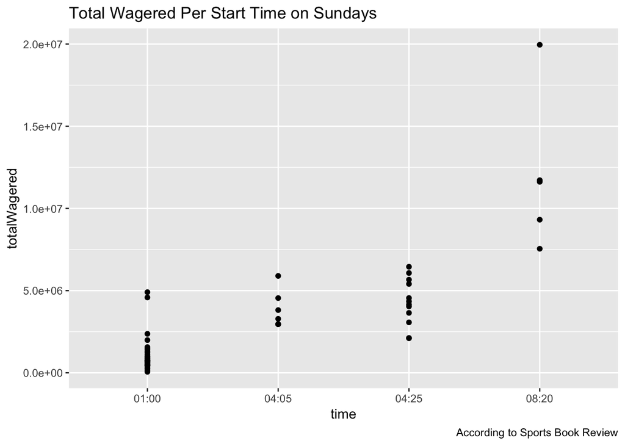

```r
graphTotalWageredByTime()
```